# Flight Delay Classification Project

Mean Girls : Shikha Goel, Katherine Minor, Muriel Pokol

Project Due: May 8, 2019

### Introduction: Flight Data

#### This data is an extract from the Airline On-Time Performance Data made available through the Bureau of Transportation Statistics of the U.S. Department of Transportation. This data specifically is a subset of air traffic through the PIT airport from the year 2018 and gives provides a lot of information of flights flying in and out of Pittsburgh inlcuding any arrival and departure delays regarding flight delays.

### Objective and Methodology

#### The objective of our project is to build a classification model that predicts whether a flight flying out of Pittsburgh will have a delayed arrival at the destination.

#### The Methodology followed by our team is outlined below :

- 1. Conduct exploratory data analysis on the data set to identify interesting relationships while helping us get familiar withthe dataset and understand the information better.
- 2. Scan the data for missing values and remove variables that are mostly null.
- 3. Feature Selection : Use l-1 regularized logistic regression and RandomForest for Feature Selection
- 4. Create training and test data for our final subset of features
- 5. Model Fits: Fit various classification models on the training data. We used Logistic Regression, LDA, QDA, Naive Bayes and Random Forests
- 6. Model Selection : Compute classification metrics and display confusion matrices that would allow us to select the best model based on performance using the test data
- 7. Fit the best model on the entire data set - this is pur final prediction model.
- 8. Use this model to make comparisons with the 2006 data.

### Data Cleaning

```r
# Read in the data
all.pit.2018 <- read.csv("all_PIT_2018.csv")

# Use a for loop to determine columns that which columns should be dropped at the offset
column.names <- names(all.pit.2018)

for (i in 1:length(column.names)){
  cat("Number of NAs in", column.names[i], "is",
      sum(is.na(all.pit.2018[,column.names[i]])),"\n", sep = " ")
}
```

```
## Number of NAs in X.1 is 0
## Number of NAs in YEAR is 0
## Number of NAs in QUARTER is 0
## Number of NAs in MONTH is 0
## Number of NAs in DAY_OF_MONTH is 0
## Number of NAs in DAY_OF_WEEK is 0
## Number of NAs in FL_DATE is 0
## Number of NAs in MKT_UNIQUE_CARRIER is 0
## Number of NAs in BRANDED_CODE_SHARE is 0
## Number of NAs in MKT_CARRIER_AIRLINE_ID is 0
## Number of NAs in MKT_CARRIER is 0
## Number of NAs in MKT_CARRIER_FL_NUM is 0
## Number of NAs in SCH_OP_UNIQUE_CARRIER is 8829
## Number of NAs in SCH_OP_CARRIER_AIRLINE_ID is 100191
## Number of NAs in SCH_OP_CARRIER is 8829
## Number of NAs in SCH_OP_CARRIER_FL_NUM is 100191
## Number of NAs in OP_UNIQUE_CARRIER is 0
## Number of NAs in OP_CARRIER_AIRLINE_ID is 0
## Number of NAs in OP_CARRIER is 0
## Number of NAs in TAIL_NUM is 0
## Number of NAs in OP_CARRIER_FL_NUM is 0
## Number of NAs in ORIGIN_AIRPORT_ID is 0
## Number of NAs in ORIGIN_AIRPORT_SEQ_ID is 0
## Number of NAs in ORIGIN_CITY_MARKET_ID is 0
## Number of NAs in ORIGIN is 0
## Number of NAs in ORIGIN_CITY_NAME is 0
## Number of NAs in ORIGIN_STATE_ABR is 0
## Number of NAs in ORIGIN_STATE_FIPS is 0
## Number of NAs in ORIGIN_STATE_NM is 0
## Number of NAs in ORIGIN_WAC is 0
## Number of NAs in DEST_AIRPORT_ID is 0
## Number of NAs in DEST_AIRPORT_SEQ_ID is 0
## Number of NAs in DEST_CITY_MARKET_ID is 0
## Number of NAs in DEST is 0
## Number of NAs in DEST_CITY_NAME is 0
## Number of NAs in DEST_STATE_ABR is 0
## Number of NAs in DEST_STATE_FIPS is 0
## Number of NAs in DEST_STATE_NM is 0
## Number of NAs in DEST_WAC is 0
## Number of NAs in CRS_DEP_TIME is 0
```

[output cut: 18 more lines]

```
## Number of NAs in CANCELLATION_CODE is 0
## Number of NAs in DIVERTED is 0
## Number of NAs in DUP is 0
## Number of NAs in CRS_ELAPSED_TIME is 0
## Number of NAs in ACTUAL_ELAPSED_TIME is 2100
## Number of NAs in AIR_TIME is 2100
## Number of NAs in FLIGHTS is 0
## Number of NAs in DISTANCE is 0
## Number of NAs in DISTANCE_GROUP is 0
## Number of NAs in CARRIER_DELAY is 82041
## Number of NAs in WEATHER_DELAY is 82041
## Number of NAs in NAS_DELAY is 82041
## Number of NAs in SECURITY_DELAY is 82041
## Number of NAs in LATE_AIRCRAFT_DELAY is 82041
## Number of NAs in X is 100213
```

```r
# Drop those unnecesary columns with 70% or more of observations as NAs.
all.pit.2018 <- all.pit.2018[,-which(names(all.pit.2018) %in%
                                  c("SCH_OP_UNIQUE_CARRIER","SCH_OP_CARRIER_AIRLINE_ID",
                                 "SCH_OP_CARRIER","SCH_OP_CARRIER_FL_NUM",
                                 "CARRIER_DELAY","WEATHER_DELAY","NAS_DELAY",
                                "SECURITY_DELAY","LATE_AIRCRAFT_DELAY","CANCELLATION_CODE",
                                 "X", "X.1", "DUP"))]

# Subset data to get only rows where the destination is Pittsburgh
all.pit.2018 <- subset(all.pit.2018, ORIGIN == "PIT")

# Omit all remaining rows that contain NAs
all.pit.2018 <- na.omit(all.pit.2018)
```

### Exploratory Data Analysis

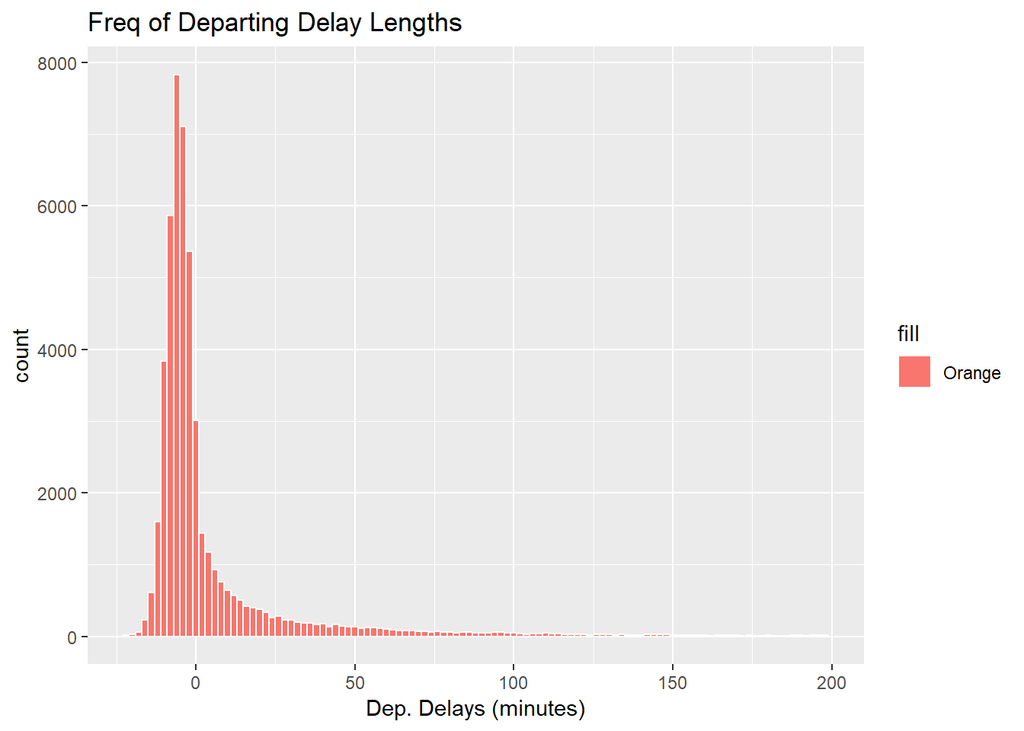

```r
# Departing Delays histogram
ggplot(subset(all.pit.2018, DEP_DELAY > -25 & DEP_DELAY < 200),
       aes(DEP_DELAY, fill = "Orange")) +
  geom_histogram(binwidth = 2, color = "White") +
  labs(title = "Freq of Departing Delay Lengths",
       x = "Dep. Delays (minutes)")
```

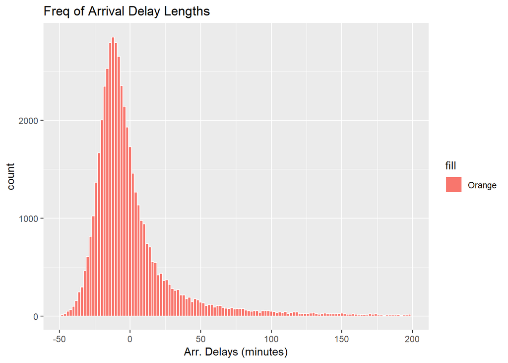

```r
# Arrival Delays histogram
ggplot(subset(all.pit.2018, ARR_DELAY > -50 & ARR_DELAY < 200),
       aes(ARR_DELAY, fill = "Orange")) +
  geom_histogram(binwidth = 2, color = "White") +
  labs(title = "Freq of Arrival Delay Lengths",
       x = "Arr. Delays (minutes)")
```

Here we create two histograms, one for departing delays and one for arrival delays. Each histogram bins by how many delays of that magnitude there were at the PIT airport in 2018. We see that most flights were not delayed, but we see that arrival delays have a greater spread than departing delays, and when arrival delays occur they tend to be longer.

#### Breakdown of Arrival Delays

> Here the arrival delays are broken down by different time frames.

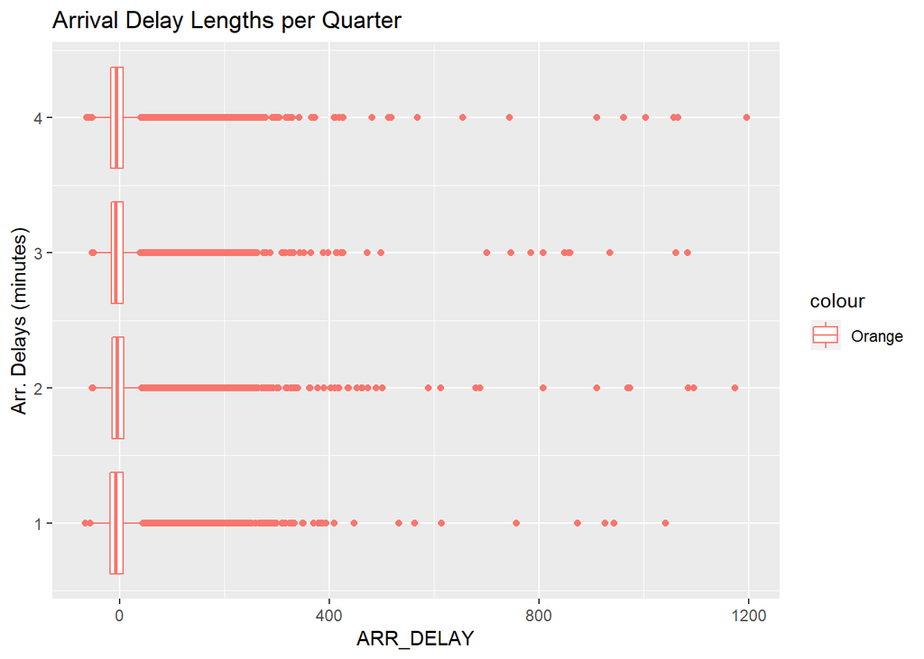

```r
ggplot(all.pit.2018,
       aes(x = QUARTER, y = ARR_DELAY, group = QUARTER, color = "Orange")) +
  geom_boxplot() +
  coord_flip() +
  labs(title = "Arrival Delay Lengths per Quarter",
       x = "Arr. Delays (minutes)")
```

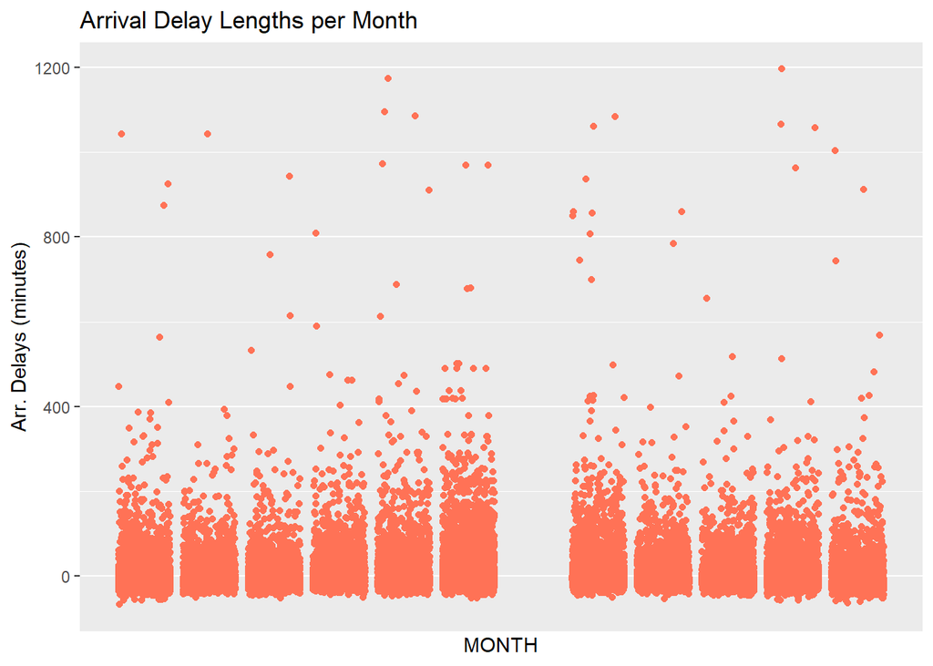

```r
ggplot(all.pit.2018,
       aes(MONTH, ARR_DELAY)) +
  geom_jitter(color = "coral1") +
  scale_x_discrete() +
  labs(title = "Arrival Delay Lengths per Month",
       y = "Arr. Delays (minutes)")
```

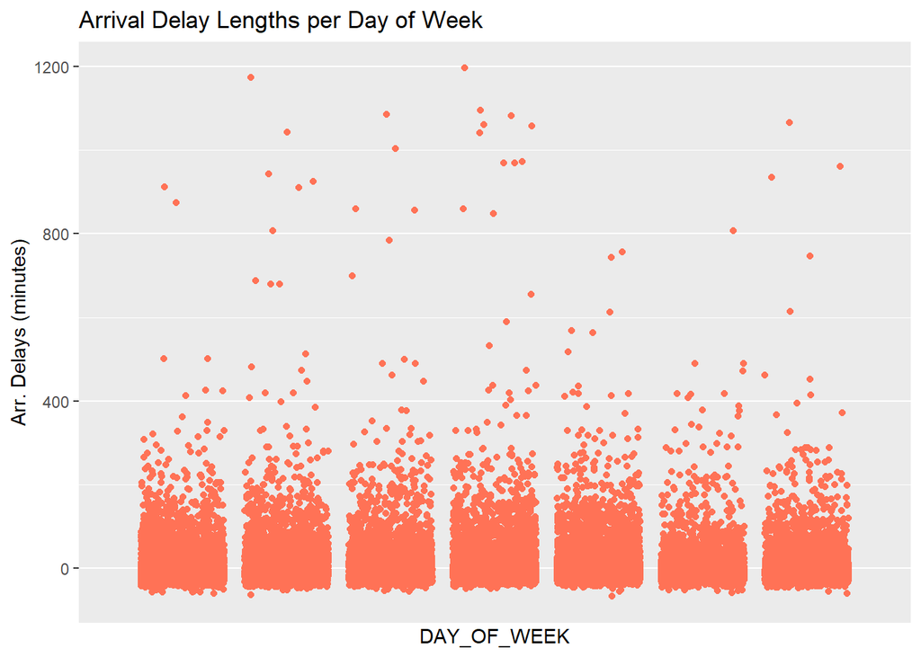

```r
ggplot(all.pit.2018,
       aes(DAY_OF_WEEK, ARR_DELAY)) +
  geom_jitter(color = "coral1") +
  scale_x_discrete() +
  labs(title = "Arrival Delay Lengths per Day of Week",
       y = "Arr. Delays (minutes)")
```

There appears to be very little information to gain from looking at arrival delays by different time periods. The frequency of the arrival delays, as well as the time of arrival delays, appear to be relatively evenly spread accross quarters, months, and days of the week.

#### Delays by Airtime

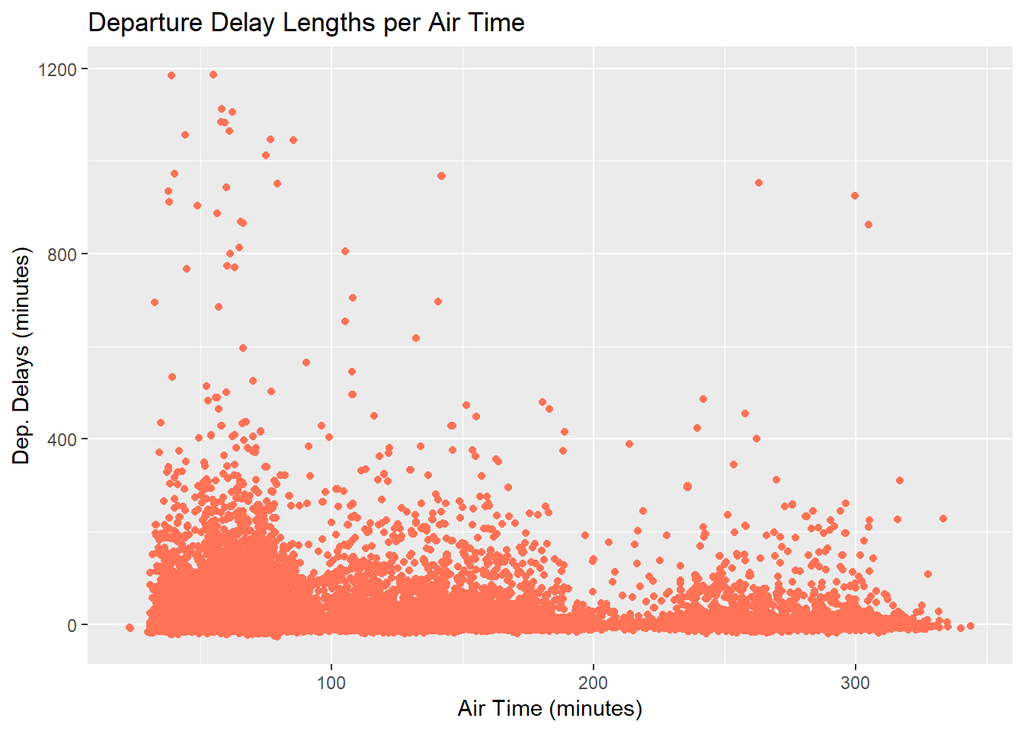

```r
ggplot(subset(all.pit.2018, AIR_TIME > -500),
       aes(AIR_TIME, DEP_DELAY)) +
  geom_jitter(color = "coral1") +
  guides(color = FALSE) +
  labs(title = "Departure Delay Lengths per Air Time",
       x = "Air Time (minutes)",
       y = "Dep. Delays (minutes)")
```

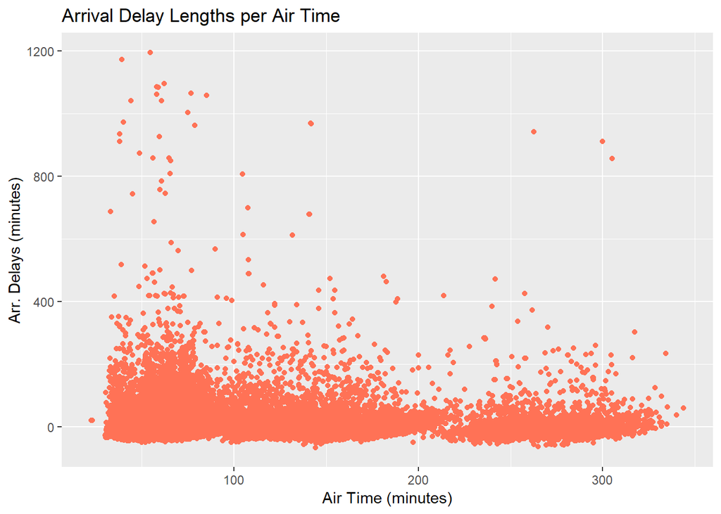

```r
ggplot(subset(all.pit.2018, AIR_TIME > -500),
       aes(AIR_TIME, ARR_DELAY)) +
  geom_jitter(color = "coral1") +
  labs(title = "Arrival Delay Lengths per Air Time",
       x = "Air Time (minutes)",
       y = "Arr. Delays (minutes)")
```

Both departing and arrival delays appear to be more frequent when the airtime is less than 200, with a small spike greater than 200 but a dip in frequency at the 200 airtime minute mark. Our assumption is that for our dataset of domestic flights, too short of a flight does not allow for the pilot to “make up time” in the air, while a longer flight is more likley to be delayed because of a greater likelihood of running into turbulance or bad weather during the fligt because the plane simply has more ground to cover.

#### Arrival Delays V/s Departure Delay

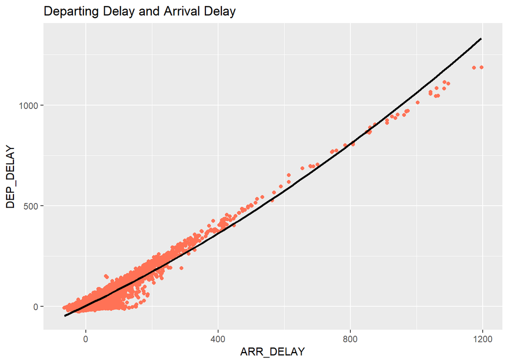

```r
ggplot(all.pit.2018,
       aes(ARR_DELAY, DEP_DELAY)) +
  geom_jitter(color = "coral1") +
  stat_smooth(method = "lm", col = "black",
              formula = y~poly(x, 2),
              data = all.pit.2018) +
  guides(color = FALSE) +
  labs(title = "Departing Delay and Arrival Delay")
```

Departing delays and arrival delays appear to be highly correlated, and based on this exploratory analysis we expect to see this relationship represented in our models below.

#### Correlation Matrices

> Here are different correlation matrices for sections of the data to determine which variables are colinear. The data was broken down into sections based on logical relationships between the columns for the purpose of readability.

**Correlation Matrix for data regarding the origin airport of the plane:**

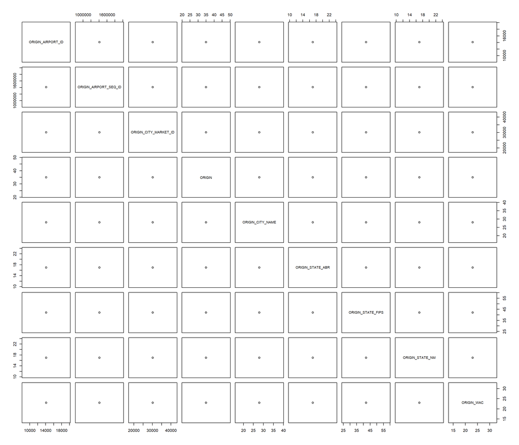

```r
pairs(~ ORIGIN_AIRPORT_ID +
        ORIGIN_AIRPORT_SEQ_ID +
        ORIGIN_CITY_MARKET_ID +
        ORIGIN +
        ORIGIN_CITY_NAME +
        ORIGIN_STATE_ABR +
        ORIGIN_STATE_FIPS +
        ORIGIN_STATE_NM +
        ORIGIN_STATE_NM +
        ORIGIN_WAC,
      data = all.pit.2018)
```

Because all of the planes originate from PIT, all of the origin-based predictors are the same. This correlation matrix is confirmation that these predictors can be removed from the dataframe used to predict arrival delays.

**Correlation Matrix for data regarding the destination airport of the plane:**

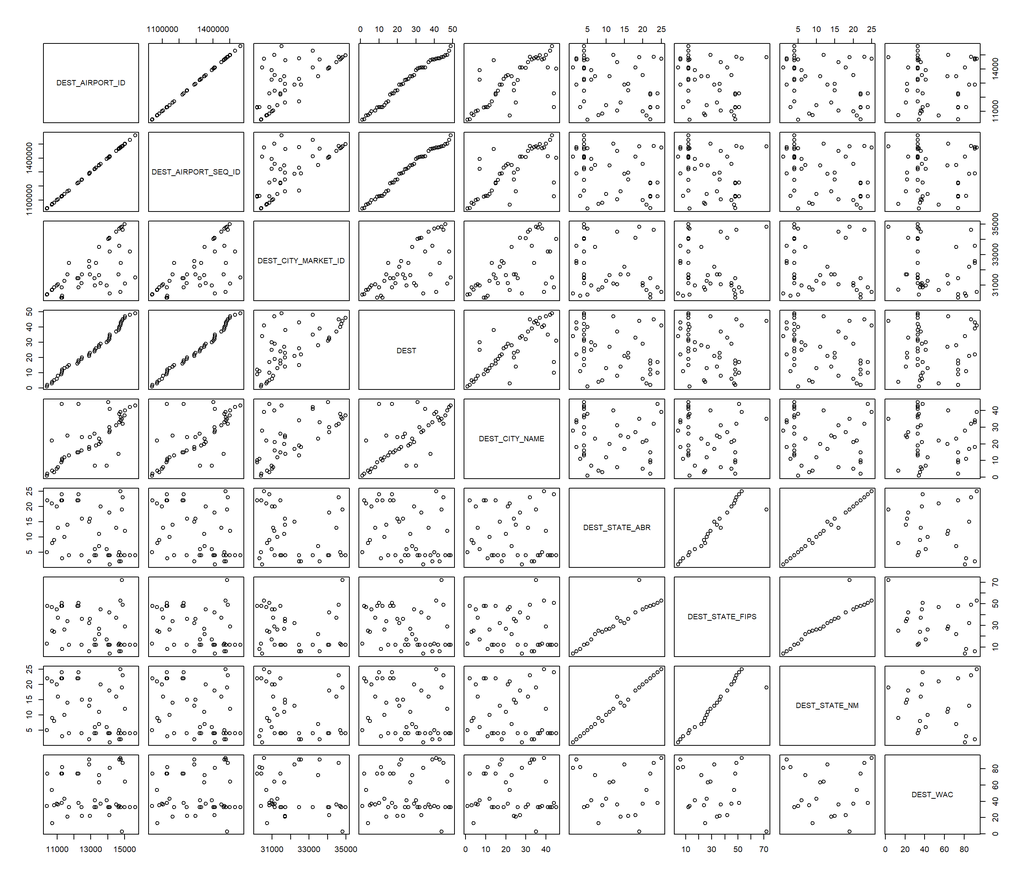

```r
pairs(~ DEST_AIRPORT_ID +
        DEST_AIRPORT_SEQ_ID +
        DEST_CITY_MARKET_ID +
        DEST +
        DEST_CITY_NAME +
        DEST_STATE_ABR +
        DEST_STATE_FIPS +
        DEST_STATE_NM +
        DEST_STATE_NM +
        DEST_WAC,
      data = all.pit.2018)
```

Beccause of such high correlations between variables among destination classifiers, implying colinearity, only DET, DEST_CITY_MARKET_ID, DEST_STATE_ABR, DEST_WAC will be chosen to use in the dataframe used to predict arrival delays.

**Correlation Matrix for data regarding the departing time and delays of the plane:**

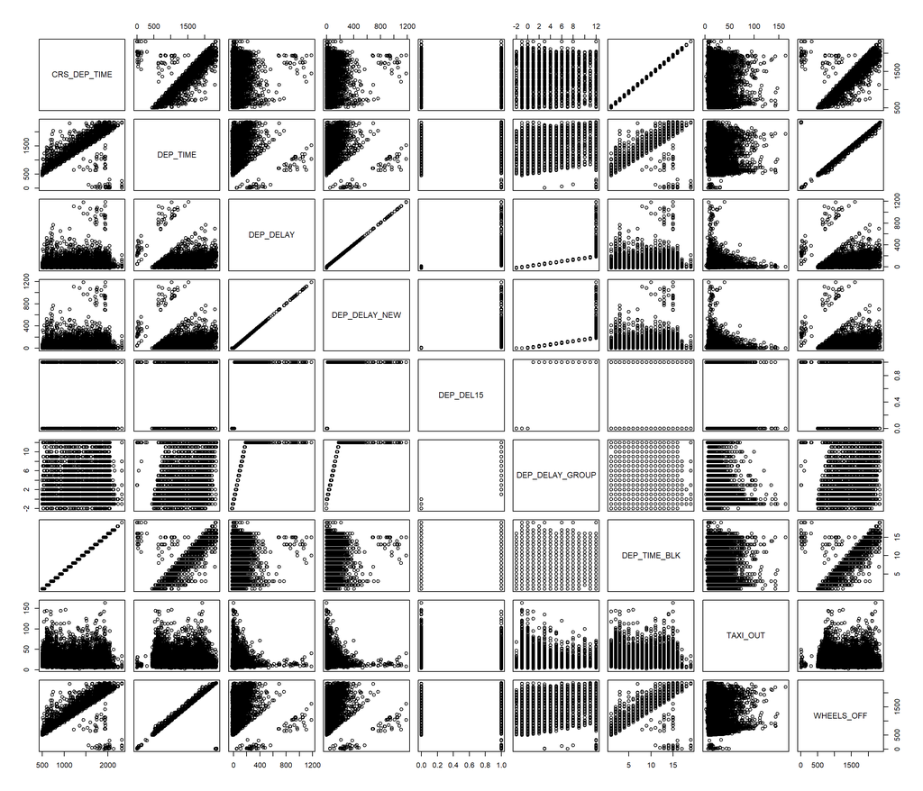

```r
pairs(~ CRS_DEP_TIME +
        DEP_TIME +
        DEP_DELAY +
        DEP_DELAY_NEW +
        DEP_DEL15 +
        DEP_DELAY_GROUP +
        DEP_TIME_BLK +
        TAXI_OUT +
        WHEELS_OFF,
      data = all.pit.2018)
```

Because of the colinearity between Departure Delay information, only Departure Delay will be kept to use in the dataframe used to predict arrival delays. Departure Time and Taxi-Out will be chosen to be used in predicting arrival delays as well.

**Correlation Matrix for data regarding the arrival time and delays of the plane:**

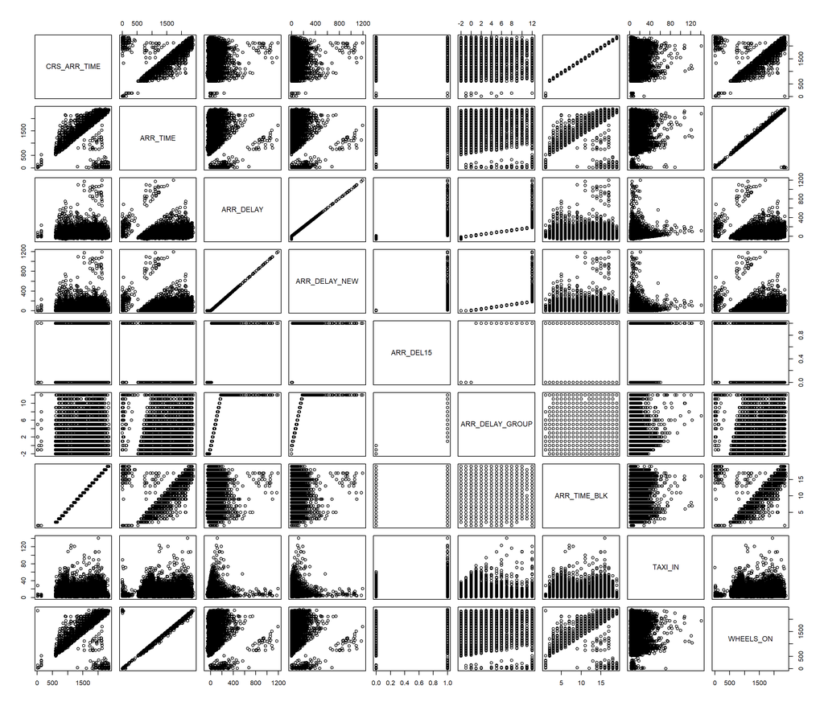

```r
pairs(~ CRS_ARR_TIME +
        ARR_TIME +
        ARR_DELAY +
        ARR_DELAY_NEW +
        ARR_DEL15 +
        ARR_DELAY_GROUP +
        ARR_TIME_BLK +
        TAXI_IN +
        WHEELS_ON,
      data = all.pit.2018)
```

There is very high correlation, implicating colinearity, between the different classifications of arrival delays. Becuase we are hoping to determine whether a flight’s arrival will be delayed by 15 minutes or more, only Arr_Delay15 will be used in the dataframe predicting arrival delays. All other predictors here are not possible to know until the flight has actually landed at its destination.

**Correlation Matrix for data regarding flight scheduling information:**

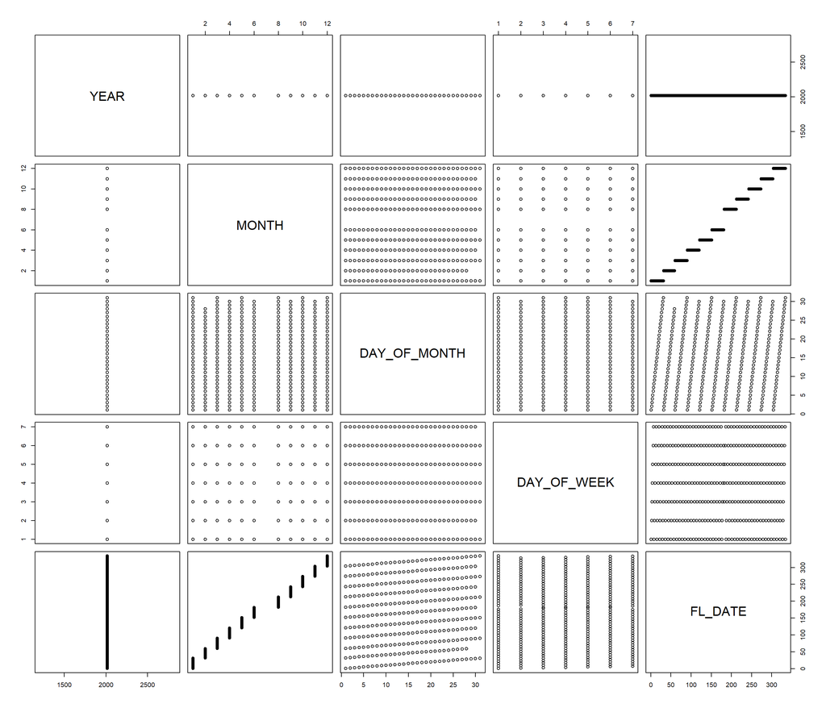

```r
pairs(~ YEAR +
        MONTH +
        DAY_OF_MONTH +
        DAY_OF_WEEK +
        FL_DATE,
      data = all.pit.2018)
```

Because all flights occur in 2018 here, year will be removed from the dataset used in predicting flight delays. Flight date is removed due to unnecessary overfitting. The predictors Month, Day of Month, and Day of Week are chosen to use in the dataframe predicting arrival delays.

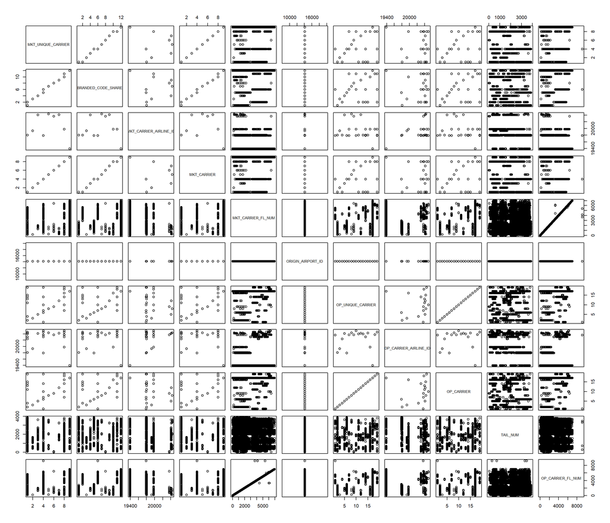

```r
pairs(~ MKT_UNIQUE_CARRIER +
        BRANDED_CODE_SHARE +
        MKT_CARRIER_AIRLINE_ID +
        MKT_CARRIER +
        MKT_CARRIER_FL_NUM +
        ORIGIN_AIRPORT_ID +
        OP_UNIQUE_CARRIER +
        OP_CARRIER_AIRLINE_ID +
        OP_CARRIER +
        TAIL_NUM +
        OP_CARRIER_FL_NUM,
      data = all.pit.2018)
```

Because of high correlation, again implicating colinearity between the different identification numbers for carriers and airlines. Flight Number and Tail Number are removed due to overfitting. MKT Carrier, MKT Carrier Airline ID, and OP Carrier are chosen to use in the dataframe predicting arrival delays.

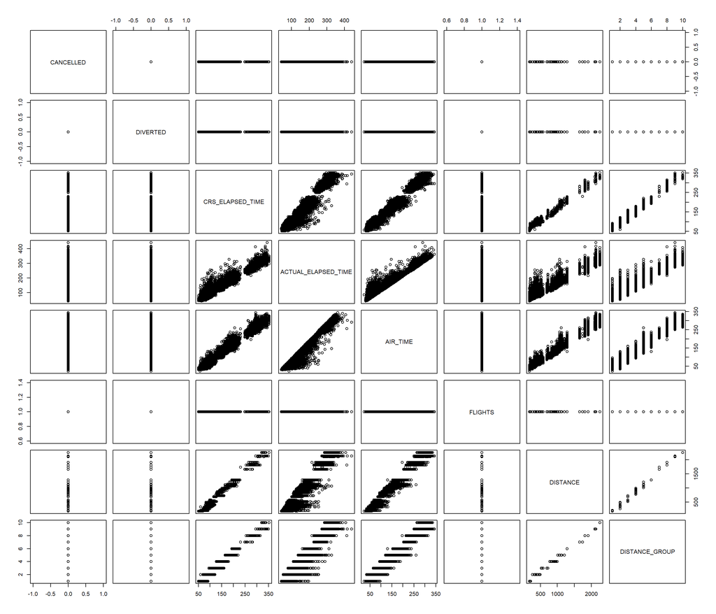

```r
pairs(~ CANCELLED +
        DIVERTED +
        CRS_ELAPSED_TIME +
        ACTUAL_ELAPSED_TIME +
        AIR_TIME +
        FLIGHTS +
        DISTANCE +
        DISTANCE_GROUP,
      data = all.pit.2018)
```

Only Airtime and Distance will be chosen to use in the dataframe predicting arrival time, as all other predictors here are very highly correlated or, in the case of diverted or cancelled, irrelevant to our goal of predicting arrival delays.

### Feature Selection

(Note : the two different subsets below are due to slight differences in the selection of Variables that had names as well as IDs. example : DEST and DEST_AIRPORT_ID). The data set referred to as “with names” was created only for classification trees to facilitate ease of read.)

```r
# Subset to only columns that are uniquely relevant based on the correlation matrices
all.pit.2018.names <- all.pit.2018[,which(names(all.pit.2018) %in%
                                  c("AIR_TIME",
                                    "DISTANCE",
                                    "DEST",
                                    "DEST_CITY_MARKET_ID",
                                    "DEST_STATE_ABR",
                                    "DEST_WAC",
                                    "DEP_DELAY",
                                    "QUARTER",
                                    "ARR_DEL15",
                                    "DEP_TIME",
                                    "TAXI_OUT",
                                    "MONTH",
                                    "DAY_OF_MONTH",
                                    "DAY_OF_WEEK",
                                    "MKT_CARRIER",
                                    "MKT_CARRIER_AIRLINE_ID",
                                    "OP_CARRIER"))]
```

```r
# Subset to only columns that are uniquely relevant based on the correlation matrices
all.pit.2018.nums <- all.pit.2018[,which(names(all.pit.2018) %in%
                                  c("AIR_TIME",
                                    "DISTANCE",
                                    "DEST_AIRPORT_ID",
                                    "DEST_CITY_MARKET_ID",
                                    "DEST_STATE_FIPS ",
                                    "DEST_WAC",
                                    "DEP_DELAY",
                                    "ARR_DEL15",
                                    "DEP_TIME",
                                    "TAXI_OUT",
                                    "MONTH",
                                    "DAY_OF_MONTH",
                                    "DAY_OF_WEEK",
                                    "QUARTER",
                                    #"MKT_CARRIER",
                                    "MKT_CARRIER_AIRLINE_ID"))]
                                    #"OP_CARRIER"
```

#### FS Lasso Logistic: Feature Selection

After reducing columns in data from colinearity, we ran two methods to determine feature selection for the classification fits. First we ran a Lasso Logistic and second a Random Forrest fit. We then compared the results of each to determine which features were of high predictive quality.

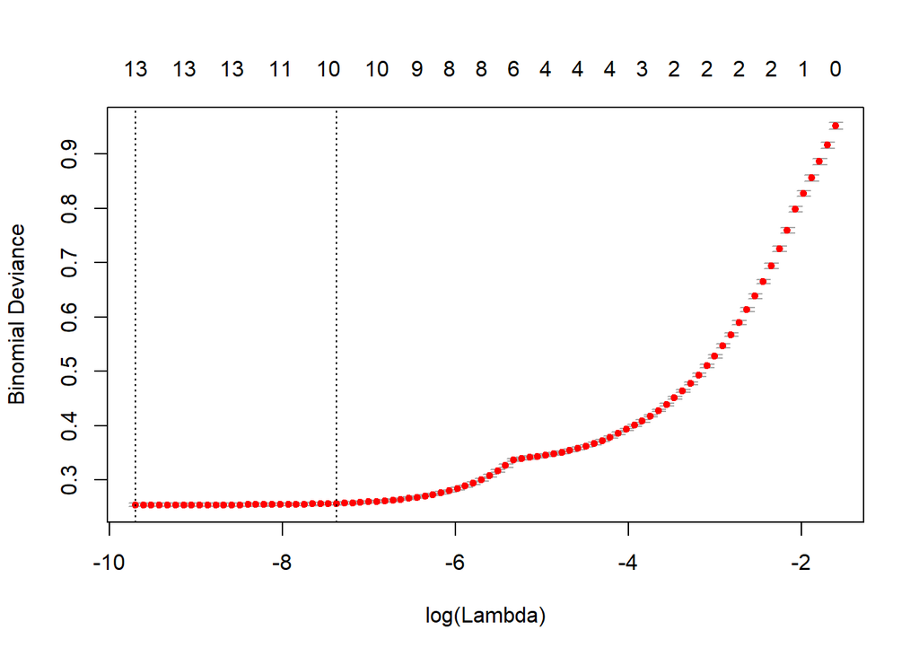

```r
# Extract covariates matrix (for lasso)
flight.x <- as.matrix(all.pit.2018.nums[, -which(names(all.pit.2018.nums) == "ARR_DEL15")])

# Extract response variable (for lasso)
flight.y <- all.pit.2018.nums$ARR_DEL15

#Code for Lasso Fit
flight.lasso <- glmnet(x = flight.x, y = flight.y, family = "binomial")

flight.lasso.cv.log <- cv.glmnet(x = flight.x, y = flight.y, family = "binomial")
plot(flight.lasso.cv.log)
```

```r
minlam <- flight.lasso.cv.log$lambda.min
coef(flight.lasso, s = minlam)
```

```
## 14 x 1 sparse Matrix of class "dgCMatrix"
##                                    1
## (Intercept)            -1.566527e+01
## QUARTER                -1.381649e-01
## MONTH                   5.383496e-02
## DAY_OF_MONTH            4.418221e-03
## DAY_OF_WEEK             2.476460e-03
## MKT_CARRIER_AIRLINE_ID  5.744954e-04
## DEST_AIRPORT_ID         3.046595e-05
## DEST_CITY_MARKET_ID    -1.394743e-04
## DEST_WAC               -3.018429e-02
## DEP_TIME                3.106007e-04
## DEP_DELAY               1.922672e-01
## TAXI_OUT                1.517841e-01
## AIR_TIME                1.412229e-01
## DISTANCE               -1.686605e-02
```

```r
oneselam <- flight.lasso.cv.log$lambda.1se

coef(flight.lasso, s = oneselam)
```

```
## 14 x 1 sparse Matrix of class "dgCMatrix"
##                                    1
## (Intercept)            -1.419694e+01
## QUARTER                 .
## MONTH                   7.219733e-03
## DAY_OF_MONTH            2.536681e-03
## DAY_OF_WEEK             .
## MKT_CARRIER_AIRLINE_ID  4.651637e-04
## DEST_AIRPORT_ID         .
## DEST_CITY_MARKET_ID    -8.365345e-05
## DEST_WAC               -2.280871e-02
## DEP_TIME                2.893260e-04
## DEP_DELAY               1.744713e-01
## TAXI_OUT                1.408777e-01
## AIR_TIME                1.147133e-01
## DISTANCE               -1.363225e-02
```

#### Random Forest: Feature Selection

```r
# Generate a random forest based on the flight training data
all.pit.2018.rf <- randomForest(as.factor(ARR_DEL15) ~ ., all.pit.2018.names)
print(all.pit.2018.rf)
```

```
##
## Call:
##  randomForest(formula = as.factor(ARR_DEL15) ~ ., data = all.pit.2018.names)
##                Type of random forest: classification
##                      Number of trees: 500
## No. of variables tried at each split: 4
##
##         OOB estimate of  error rate: 3.76%
## Confusion matrix:
##       0    1 class.error
## 0 39429  476  0.01192833
## 1  1362 7613  0.15175487
```

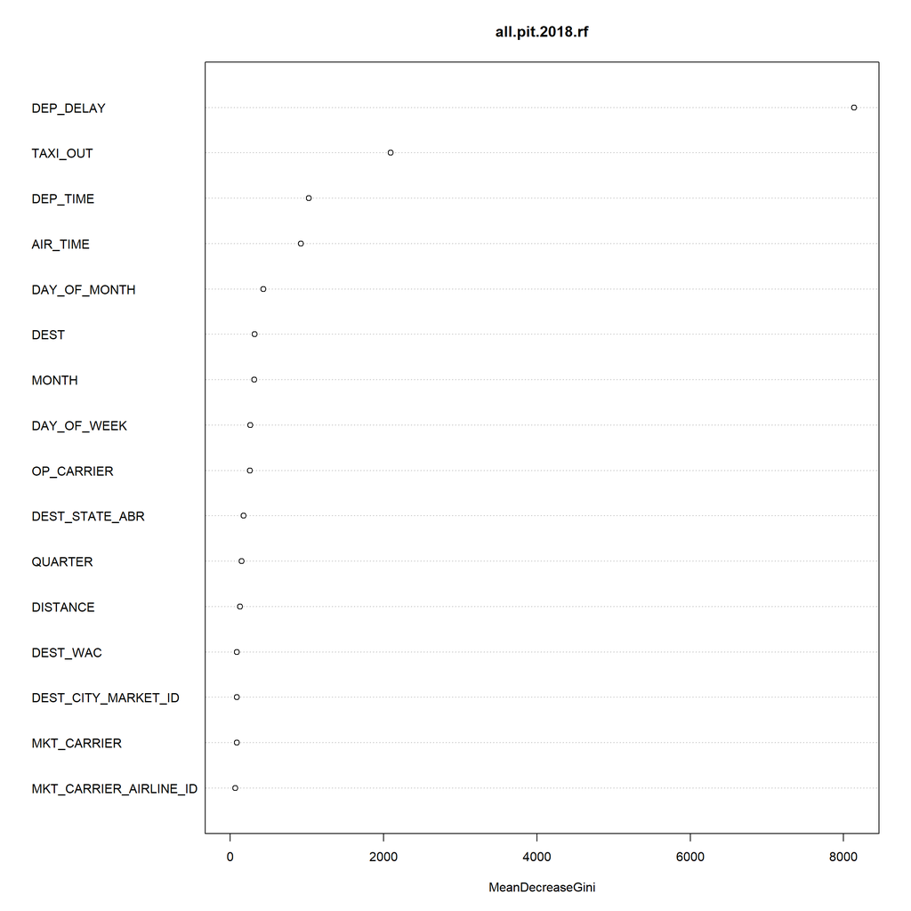

```r
# Plot important variables
varImpPlot(all.pit.2018.rf)
```

```r
# Subset to only columns that are uniquely relevant based on the correlation matrices
all.pit.2018.names <- all.pit.2018[,which(names(all.pit.2018) %in%
                                  c("AIR_TIME",
                                    "DISTANCE",
                                    "DEST",
                                    "DEST_STATE_ABR",
                                    "DEST_WAC",
                                    "DEP_DELAY",
                                    "QUARTER",
                                    "ARR_DEL15",
                                    "DEP_TIME",
                                    "TAXI_OUT",
                                    "MONTH",
                                    "DAY_OF_MONTH",
                                    "DAY_OF_WEEK"))]
```

```r
# Subset to only columns that are uniquely relevant based on the correlation matrices
all.pit.2018.nums <- all.pit.2018[,which(names(all.pit.2018) %in%
                                  c("AIR_TIME",
                                    "DISTANCE",
                                    "DEST_AIRPORT_ID",
                                    "DEST_STATE_FIPS ",
                                    "DEST_WAC",
                                    "DEP_DELAY",
                                    "ARR_DEL15",
                                    "DEP_TIME",
                                    "TAXI_OUT",
                                    "MONTH",
                                    "DAY_OF_MONTH",
                                    "DAY_OF_WEEK",
                                    "QUARTER"))]
```

# Training and Testing Data

```r
set.seed(531)

# Randomly select 20% of the data to be held out for model validation
names.test.indexes <- sample(1:nrow(all.pit.2018.names),
                       round(0.2 * nrow(all.pit.2018.names)))
names.train.indexes <- setdiff(1:nrow(all.pit.2018.names), names.test.indexes)

# Just pull the covar
all.pit.2018.names.train <- all.pit.2018.names[names.train.indexes, 1:ncol(all.pit.2018.names)]
all.pit.2018.names.test <- all.pit.2018.names[names.test.indexes, 1:ncol(all.pit.2018.names)]
```

```r
set.seed(531)

# Randomly select 20% of the data to be held out for model validation
nums.test.indexes <- sample(1:nrow(all.pit.2018.nums),
                       round(0.2 * nrow(all.pit.2018.nums)))
nums.train.indexes <- setdiff(1:nrow(all.pit.2018.nums), nums.test.indexes)

# Put all the information based on the above indices into two separate data sets
all.pit.2018.nums.train <- all.pit.2018.nums[nums.train.indexes, 1:ncol(all.pit.2018.nums)]
all.pit.2018.nums.test <- all.pit.2018.nums[nums.test.indexes, 1:ncol(all.pit.2018.nums)]
```

### Model Selection

> In this section we take the training data and fit various classification models. The models we considered are : Logistic Regression, Linear Discriminant Analysis (LDA), Quadratic Discriminant Analysis(QDA), Naive Bayes, Pruned Trees and Random Forests. Due to a large number of predictor variables we chose not to use K-Nearest Neighbors.

#### Decision Trees

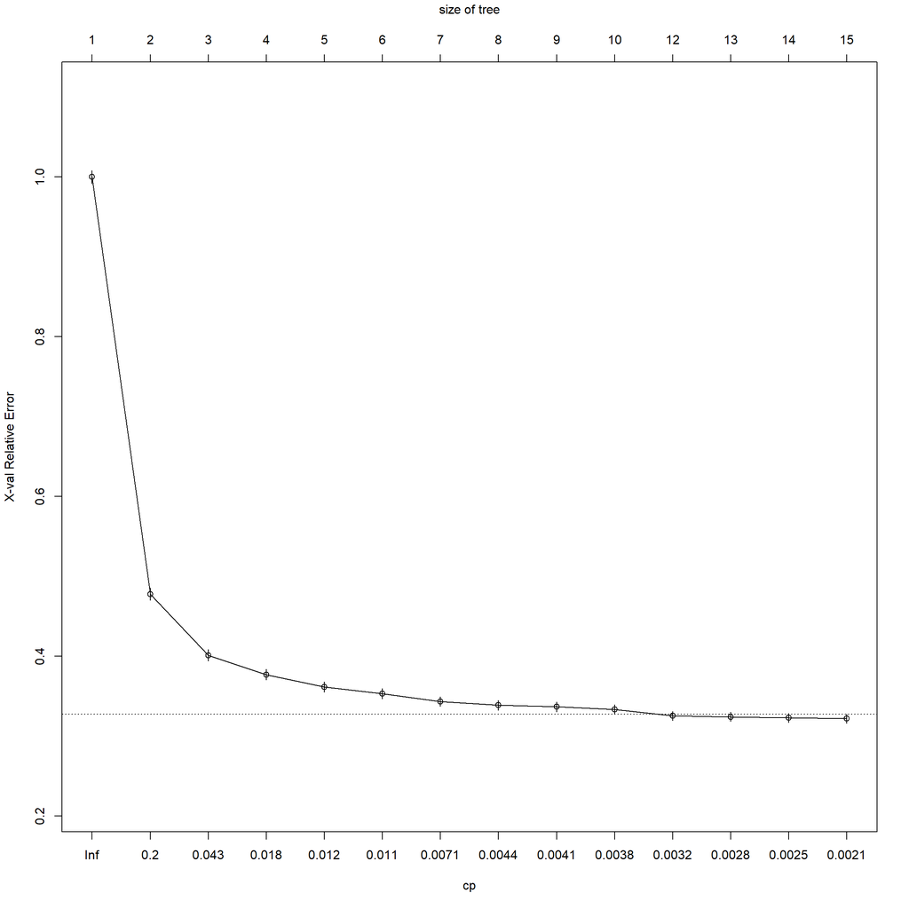

```r
# Create a full tree and plot out its complexity parameter graph
all.pit.2018.full <- rpart(ARR_DEL15 ~ ., data = all.pit.2018.names.train,
                        control = rpart.control(minsplit=100, cp=0.002))
plotcp(all.pit.2018.full)
```

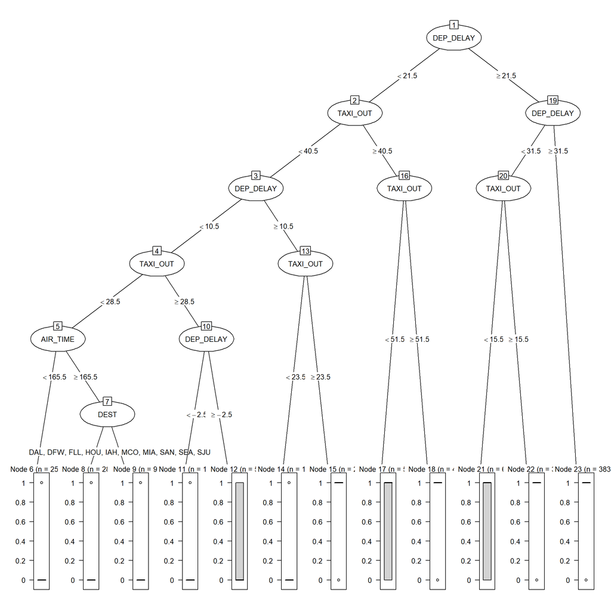

```r
# Prune and plot the tree
all.pit.2018.pruned <- prune(all.pit.2018.full, cp = 0.0033)
all.pit.2018.pruned.party <- as.party(all.pit.2018.pruned)
plot(all.pit.2018.pruned.party, gp = gpar(fontsize = 10))
```

Looking here at a fully grown and pruned tree, we see that Departure Delay and taxi-out time are both incredibly important indicators of whether a flight will have a delayed arrival time. However, we do see air time and destination as relevant factors but not as important as Departure Delay.

```r
# Generate a random forest based on the flight training data
all.pit.2018.rf <- randomForest(as.factor(ARR_DEL15) ~ ., all.pit.2018.names.train)
print(all.pit.2018.rf)
```

```
##
## Call:
##  randomForest(formula = as.factor(ARR_DEL15) ~ ., data = all.pit.2018.names.train)
##                Type of random forest: classification
##                      Number of trees: 500
## No. of variables tried at each split: 3
##
##         OOB estimate of  error rate: 4.12%
## Confusion matrix:
##       0    1 class.error
## 0 31516  433  0.01355285
## 1  1178 5977  0.16464011
```

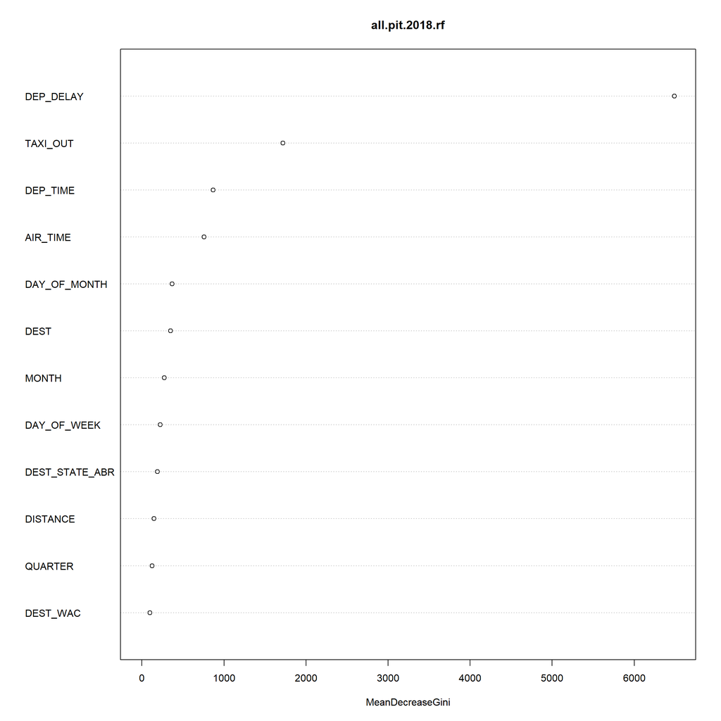

```r
# Plot important variables
varImpPlot(all.pit.2018.rf)
```

Here a random forest is generated from our training data. Departure Delay is much more important than the other predictors, but taxi-out time, departure time, and air time are other noteworthy factors.

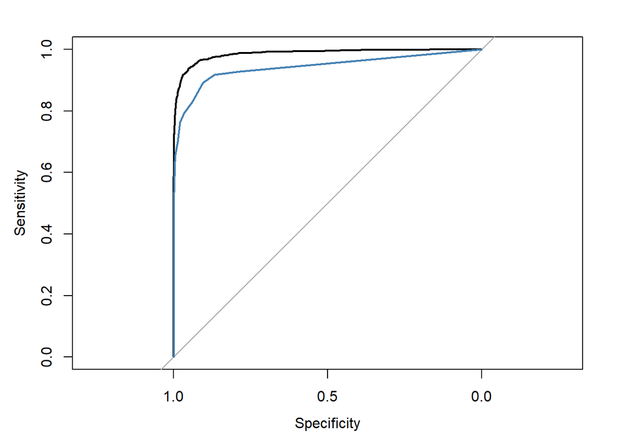

```r
# For Random Forest, find the probability that a flight is delayed in the test data, based on our predictive model
all.pit.2018.rf.prob <- predict(all.pit.2018.rf, all.pit.2018.names.test, type = "prob")
all.pit.2018.rf.probyes <- all.pit.2018.rf.prob[, 2]

# For Pruned Tree, find the probability that a flight is delayed in the test data, based on our predictive model
all.pit.2018.pruned.prob <- predict(all.pit.2018.pruned, all.pit.2018.names.test)
all.pit.2018.pruned.probyes <- all.pit.2018.pruned.prob

# Plot the ROC curve of the Random Forest
plot.roc.rf <- roc(all.pit.2018.names.test$ARR_DEL15, all.pit.2018.rf.probyes)
plot(plot.roc.rf)

# Add the ROC curve of the Pruned Tree t to the same plot
plot.roc.pruned <- roc(all.pit.2018.names.test$ARR_DEL15, all.pit.2018.pruned.probyes)
plot(plot.roc.pruned, col = "steelblue", add = TRUE)
```

```r
# Print out the area under each curve
plot.roc.rf$auc
```

```
## Area under the curve: 0.986
```

```r
plot.roc.pruned$auc
```

```
## Area under the curve: 0.9412
```

#### Logistic

```r
pit.logit <- glm(ARR_DEL15 ~ ., family = binomial(), data = all.pit.2018.nums.train)

summary(pit.logit)
```

```
##
## Call:
## glm(formula = ARR_DEL15 ~ ., family = binomial(), data = all.pit.2018.nums.train)
##
## Deviance Residuals:
##     Min       1Q   Median       3Q      Max
## -3.1005  -0.1863  -0.0877  -0.0407   4.6305
##
## Coefficients:
##                   Estimate Std. Error z value Pr(>|z|)
## (Intercept)     -7.846e+00  3.006e-01 -26.098  < 2e-16 ***
## QUARTER         -2.592e-01  1.038e-01  -2.497  0.01251 *
## MONTH            9.101e-02  3.345e-02   2.721  0.00652 **
## DAY_OF_MONTH     4.786e-03  3.078e-03   1.555  0.11997
## DAY_OF_WEEK     -9.307e-03  1.380e-02  -0.675  0.49999
## DEST_AIRPORT_ID -3.445e-05  2.075e-05  -1.660  0.09697 .
## DEST_WAC        -3.191e-02  2.220e-03 -14.371  < 2e-16 ***
## DEP_TIME         3.131e-04  5.933e-05   5.277 1.31e-07 ***
## DEP_DELAY        1.926e-01  2.865e-03  67.243  < 2e-16 ***
## TAXI_OUT         1.532e-01  2.802e-03  54.681  < 2e-16 ***
## AIR_TIME         1.430e-01  3.037e-03  47.085  < 2e-16 ***
## DISTANCE        -1.698e-02  3.826e-04 -44.389  < 2e-16 ***
## ---
## Signif. codes:  0 '***' 0.001 '**' 0.01 '*' 0.05 '.' 0.1 ' ' 1
##
## (Dispersion parameter for binomial family taken to be 1)
##
##     Null deviance: 37217  on 39103  degrees of freedom
## Residual deviance: 10002  on 39092  degrees of freedom
## AIC: 10026
##
## Number of Fisher Scoring iterations: 8
```

#### LDA

```r
pit.lda <- lda( ARR_DEL15 ~ ., data = all.pit.2018.nums.train)

summary(pit.lda)
```

```
##         Length Class  Mode
## prior    2     -none- numeric
## counts   2     -none- numeric
## means   22     -none- numeric
## scaling 11     -none- numeric
## lev      2     -none- character
## svd      1     -none- numeric
## N        1     -none- numeric
## call     3     -none- call
## terms    3     terms  call
## xlevels  0     -none- list
```

#### QDA

```r
pit.qda <- qda( as.factor(ARR_DEL15) ~ ., data = all.pit.2018.nums.train)

summary(pit.qda)
```

```
##         Length Class  Mode
## prior     2    -none- numeric
## counts    2    -none- numeric
## means    22    -none- numeric
## scaling 242    -none- numeric
## ldet      2    -none- numeric
## lev       2    -none- character
## N         1    -none- numeric
## call      3    -none- call
## terms     3    terms  call
## xlevels   0    -none- list
```

#### Naive Bayes

```r
pit.nb <- NaiveBayes(as.factor(ARR_DEL15) ~ ., data = all.pit.2018.nums.train,
                     usekernel =TRUE)

summary(pit.nb)
```

```
##           Length Class      Mode
## apriori    2     table      numeric
## tables    11     -none-     list
## levels     2     -none-     character
## call       4     -none-     call
## x         11     data.frame list
## usekernel  1     -none-     logical
## varnames  11     -none-     character
```

### Model Selection

> For our classification problem, we reasoned that we care more about ensuring that there are low False Negatives ( or equivalently high True Positives) and so we pick the variable with the highest Sensitivity. This is because, passengers would be happier about a flight arriving on time that they think was delayed rather than a flight getting delayed after they’re assured it is on time.

In this section , we take all the different fitted models and use it to find conditional probabilities P(Y = 1/X= x) for our test data inorder to compare the peformance of each of the models. The classMetrics functions gives us the confusion matrix for each method as well as the Specificity, Sensitivity and Accuracy of each model.

```r
lda.pred <- predict(pit.lda, newdata = all.pit.2018.nums.test)$posterior
qda.pred <-  predict(pit.qda, newdata = all.pit.2018.nums.test)$posterior
nb.pred <- predict(pit.nb, newdata = all.pit.2018.nums.test)$posterior
rforest.pred <- predict(all.pit.2018.rf, newdata = all.pit.2018.names.test, type="prob")

logit.score <- predict(pit.logit, newdata = all.pit.2018.nums.test,type = "response")
lda.score <- lda.pred[,2]
qda.score <- qda.pred[,2]
nb.score  <- nb.pred[,2]
rforest.score <- rforest.pred[,2]

observed <- all.pit.2018.nums.test$ARR_DEL15
```

```r
classMetrics <- function(score, y, cutoff) {


  yhat <-  rep(0,length(y))
  for (i in 1:length(score)) {
    if ( score[i] >= cutoff) {
      yhat[i] = 1
    }
    else{
      yhat[i] = 0
    }
  }

  predicted <- yhat
  observed <- y
  conf.mat <- table(predicted, observed)

  TP <- sum(yhat==1 & y == 1)
  TN <- sum(yhat == 0 & y == 0)
  FP <- sum(yhat == 1 & y == 0)
  FN <- sum(yhat == 0 & y== 1)



  total <- TP + TN + FP + FN
  accuracy <- (TP + TN)/total
  sensitivity <- TP/(TP + FN)
  specificity <- TN/(TN + FP)


  perf <- setNames(c(accuracy, sensitivity,specificity),
                   nm = c("accuracy",
                          "sensitivity","specificity"))



  output <- list("conf.mat" = conf.mat, "perf" = perf)

  return(output)
}



classMetrics(logit.score, observed, cutoff = 0.5)
```

```
## $conf.mat
##          observed
## predicted    0    1
##         0 7796  347
##         1  160 1473
##
## $perf
##    accuracy sensitivity specificity
##   0.9481383   0.8093407   0.9798894
```

```r
classMetrics(lda.score, observed, cutoff = 0.5)
```

```
## $conf.mat
##          observed
## predicted    0    1
##         0 7900  900
##         1   56  920
##
## $perf
##    accuracy sensitivity specificity
##   0.9022095   0.5054945   0.9929613
```

```r
classMetrics(qda.score, observed, cutoff = 0.5)
```

```
## $conf.mat
##          observed
## predicted    0    1
##         0 7657  275
##         1  299 1545
##
## $perf
##    accuracy sensitivity specificity
##   0.9412848   0.8489011   0.9624183
```

```r
classMetrics(nb.score, observed, cutoff = 0.5)
```

```
## $conf.mat
##          observed
## predicted    0    1
##         0 7879  588
##         1   77 1232
##
## $perf
##    accuracy sensitivity specificity
##   0.9319763   0.6769231   0.9903218
```

```r
classMetrics(rforest.score, observed, cutoff = 0.5)
```

```
## $conf.mat
##          observed
## predicted    0    1
##         0 7863  284
##         1   93 1536
##
## $perf
##    accuracy sensitivity specificity
##   0.9614362   0.8439560   0.9883107
```

#### We have a winner! As we can see from the above outputs, QDA provides us the highest sensitivity!

### Final Model Fit on the selected model : QDA

```r
pit.qda.final <- qda( as.factor(ARR_DEL15) ~ ., data = all.pit.2018.nums)

pit.qda.final$prior
```

```
##         0         1
## 0.8163871 0.1836129
```

```r
pit.qda.final$means
```

```
##    QUARTER    MONTH DAY_OF_MONTH DAY_OF_WEEK DEST_AIRPORT_ID DEST_WAC
## 0 2.454930 6.535722     15.79145    3.945320        12402.53 41.28575
## 1 2.417047 6.424958     15.45181    3.769916        12419.23 39.16045
##   DEP_TIME DEP_DELAY TAXI_OUT AIR_TIME DISTANCE
## 0 1186.261 -3.008896 14.47054 96.42052 646.5948
## 1 1467.247 56.657270 23.40379 99.13571 628.7827
```

```r
# Read in the data
all.pit.2006 <- read.csv("all_PIT_2006.csv")

# Use a for loop to determine which columns should be dropped at the offset
column.names <- names(all.pit.2006)

for (i in 1:length(column.names)){

  cat("Number of NAs in", column.names[i], "is",
      sum(is.nan(all.pit.2006[, column.names[i]])),"\n", sep = " ")

}
```

[output not shown]

```r
# Drop those columns
all.pit.2006 <- all.pit.2006[, -which(names(all.pit.2006) %in%
                                  c("SCH_OP_UNIQUE_CARRIER","SCH_OP_CARRIER_AIRLINE_ID",
                                 "SCH_OP_CARRIER","SCH_OP_CARRIER_FL_NUM",
                                 "CarrierDelay","WeatherDelay","NASDelay",
                                "SecurityDelay","LateAircraftDelay","CancellationCode",
                                 "X", "X.1", "DUP"))]

# Omit all remaining rows that contain NAs
all.pit.2006 <- na.omit(all.pit.2006)

all.pit.2006 <- subset(all.pit.2006, Origin == "PIT")

all.pit.2006$DEST_AIRPORT_ID <- all.pit.2018$DEST_AIRPORT_ID[match(all.pit.2006$Dest, all.pit.2018$DEST)]

all.pit.2006 <- na.omit(all.pit.2006)

all.pit.2006.nums <- all.pit.2006[,which(names(all.pit.2006) %in%
                                  c("AirTime",
                                    "Distance",
                                    "DestWac",
                                    "DepDelay",
                                    "ArrDel15",
                                    "DepTime",
                                    "TaxiOut",
                                    "Month",
                                    "DayofMonth",
                                    "DayOfWeek",
                                    "Quarter",
                                    "DEST_AIRPORT_ID"))]

names(all.pit.2006.nums) = c("QUARTER", "MONTH", "DAY_OF_MONTH", "DAY_OF_WEEK", "AIR_TIME", "ARR_DEL15", "DEP_DELAY", "DEP_TIME", "DEST_WAC", "DISTANCE", "TAXI_OUT", "DEST_AIRPORT_ID")


qda.pred.2006.prob <- predict(pit.qda.final, all.pit.2006.nums)

qda.pred.2006 <- qda.pred.2006.prob$class


conf.mat.2006 <- table(qda.pred.2006, all.pit.2006.nums$ARR_DEL15)


sensitivity.2006 <- conf.mat.2006[2,2]/sum(conf.mat.2006[,2])


prop.table(table(all.pit.2006.nums$ARR_DEL15))
```

```
##
##        0        1
## 0.758155 0.241845
```

```r
prop.table(table(all.pit.2018.nums$ARR_DEL15))
```

```
##
##         0         1
## 0.8163871 0.1836129
```

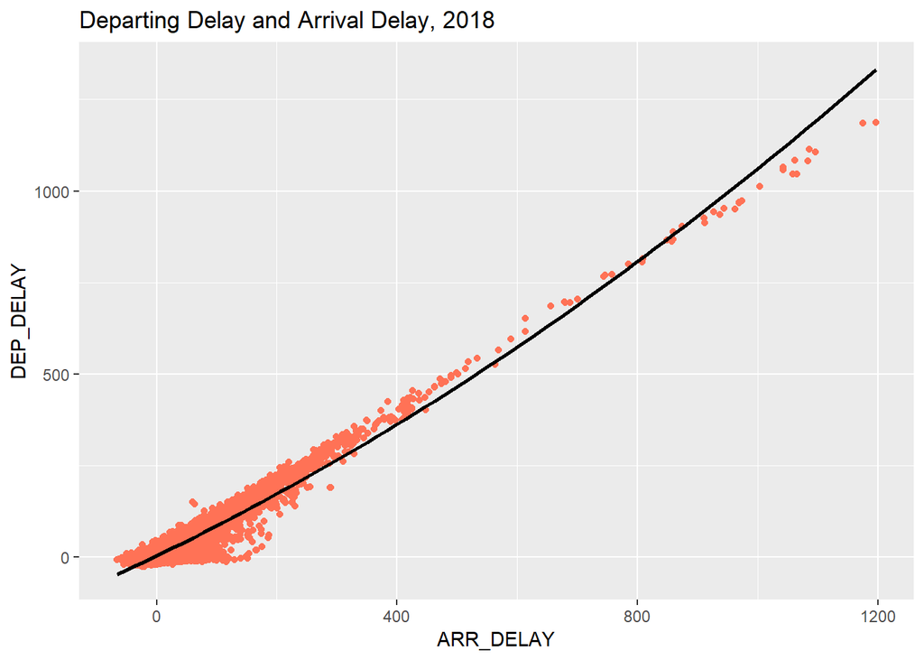

```r
ggplot(all.pit.2018,
       aes(ARR_DELAY, DEP_DELAY)) +
  geom_jitter(color = "coral1") +
  stat_smooth(method = "lm", col = "black",
              formula = y~poly(x, 2),
              data = all.pit.2018) +
  guides(color = FALSE) +
  labs(title = "Departing Delay and Arrival Delay, 2018")
```

[figure not shown]

```r
ggplot(all.pit.2006,
       aes(ArrDelay, DepDelay)) +
  geom_jitter(color = "coral1") +
  stat_smooth(method = "lm", col = "black",
              formula = y~poly(x, 2),
              data = all.pit.2006) +
  guides(color = FALSE) +
  labs(title = "Departing Delay and Arrival Delay, 2016")
```

- We used the 2018 delay model to predict delays in 2006. The model resulted in a sensitivity of 77.244898% which is less than what we obtained on the 2018 data.
- There are differences in the data between 2006 and 2018. First the proportion of arrival delays has decreased from 24% in 2006 to 18% in 2018. We also see departure delays are less correlated with arrival delays when viewing the two scatterplots side by side. This suggests other operations in the 2006 data may be driving 2006 arrival delays that are not as significantly found in the 2018 data with which we created the model on.